[figure not shown]

# **Analyze Participant Data**

> **Notebook Author:** Brian Keith (bkeith9@gatech.edu)

> **Data Citation:**
> - Andreas Miltiadous and Katerina D. Tzimourta and Theodora Afrantou and Panagiotis Ioannidis and Nikolaos Grigoriadis and Dimitrios G. Tsalikakis and Pantelis Angelidis and Markos G. Tsipouras and Evripidis Glavas and Nikolaos Giannakeas and Alexandros T. Tzallas (2023). A dataset of EEG recordings from: Alzheimer's disease, Frontotemporal dementia and Healthy subjects. OpenNeuro. [Dataset] doi: doi:10.18112/openneuro.ds004504.v1.0.6

> **Data Source:**
> - Dataset download as a zip file from: https://nemar.org/dataexplorer/detail?dataset_id=ds004504

> **Data Information:**
> - Cognitive and neuropsychological state was evaluated by the international Mini-Mental State Examination (**MMSE**)
>   - The MMSE score ranges from 0 to 30, with *a lower MMSE indicating more severe cognitive decline*.
> - Recordings include the EEG signal from 19 scalp electrodes `Fp1`, `Fp2`, `F7`, `F3`, `Fz`, `F4`, `F8`, `T3`, `C3`, `Cz`, `C4`, `T4`, `T5`, `P3`, `Pz`, `P4`, `T6`, `O1`, & `O2`, and 2 reference electrodes, placed according to the 10–20 international system (`A1` & `A2`).
>   - Sampling Rate = 500 Hz
>   - Resolution = 10 uV/mm
>   - Each recording lasted approximately 13.5 min for the AD group (min = 5.1, max = 21.3), 12 min for the FTD group (min = 7.9, max = 16.9), and 13.8 min for the CN group (min = 12.5, max = 16.5).
>     - In total, 485.5 min of AD, 276.5 min of FTD, and 402 min of CN recordings were collected and are included in the dataset.
> - 88 participants total
>   - Alzheimer’s disease (**AD**) patients (n=36)
>     - `Group = A`
>   - Frontotemporal dementia (**FTD**) patients (n=23)
>     - `Group = F`
>   - Healthy controls (**CN**) participants (n=29)
>     - `Group = C`

# Initial Tasks

## Set Params & Load Necessary Libraries

```python
SEED_VAL = 903027850 #GTID
SENSORS = [
    'Fp1', 'Fp2',
    'F3', 'F4',
    'C3', 'C4',
    'P3', 'P4',
    'O1', 'O2',
    'F7', 'F8',
    'T3', 'T4',
    'T5', 'T6',
    'Fz', 'Cz',
    'Pz',
]
PALETTE = [
    '#003057',
    '#66829a',
    '#857437',
    '#BFB37C',
    '#54585A',
    '#a9abac',
]


import pathlib
import pandas as pd
import numpy as np
import pickle
import matplotlib.pyplot as plt
from math import ceil

pd.set_option('display.max_columns', 500)
pd.set_option('display.max_colwidth', None)
pd.set_option('display.max_rows', 200)
plt.rcParams["font.family"] = "Georgia"

import warnings
warnings.simplefilter(action='ignore', category=FutureWarning)

#custom utils module from helpers/utils.py
from helpers.utils import printmd, export_code
from helpers.calcs import calc_rbp
```

## Read in Data

```python
data_file = 'data/ConsolidatedParticipantData.pkl'

with open(data_file, 'rb') as f:
    data_dict = pickle.load(f)

participants = data_dict['participants']
labels = data_dict['labels']
data_raw = data_dict['data_raw']
data_pre = data_dict['data_pre']

printmd('# <b><u>Data Summary</u></b>')
printmd(f'## <u>Participant Data Sample Preview:</u>')
print('Number of participants:', len(participants))
for i in participants.Group.unique():
    print(f'# of participants in Group {i}:', len(participants[participants.Group == i]))
display(participants.sample(5, random_state=SEED_VAL))
participants.info()

printmd(f'## <u>Label Data Sample Preview:</u>')
display(labels.sample(5, random_state=SEED_VAL))
labels.info()

printmd(f'## <u>EEG Data (Raw) Sample Preview:</u>')
display(data_raw.sample(5, random_state=SEED_VAL))
data_raw.info()

printmd(f'## <u>EEG Data (Preprocessed) Sample Preview:</u>')
display(data_pre.sample(5, random_state=SEED_VAL))
data_pre.info()
```

**Data Summary**

Participant Data Sample Preview:

```
Number of participants: 88
# of participants in Group A: 36
# of participants in Group C: 29
# of participants in Group F: 23
```

|  | participant_id | Gender | Age | Group | MMSE |
| --- | --- | --- | --- | --- | --- |
| 20 | sub-021 | M | 79 | A | 22 |
| 47 | sub-048 | M | 65 | C | 30 |
| 23 | sub-024 | F | 69 | A | 20 |
| 38 | sub-039 | M | 70 | C | 30 |
| 50 | sub-051 | F | 75 | C | 30 |

```
<class 'pandas.core.frame.DataFrame'>
RangeIndex: 88 entries, 0 to 87
Data columns (total 5 columns):
 #   Column          Non-Null Count  Dtype
---  ------          --------------  -----
 0   participant_id  88 non-null     object
 1   Gender          88 non-null     object
 2   Age             88 non-null     int64
 3   Group           88 non-null     object
 4   MMSE            88 non-null     int64
dtypes: int64(2), object(3)
memory usage: 3.6+ KB
```

Label Data Sample Preview:

|  | participant_id | labels | type | theta | radius | X | Y | Z | sph_theta | sph_phi | sph_radius | urchan | ref |
| --- | --- | --- | --- | --- | --- | --- | --- | --- | --- | --- | --- | --- | --- |
| 297 | sub-016 | T3 | EEG | -100.776424 | 0.534588 | -16.0187 | 84.1611 | -9.346 | 100.776424 | -6.225806 | 86.18026 | 13 | A1 A2 |
| 1240 | sub-066 | C4 | EEG | 99.224598 | 0.260682 | -10.9003 | -67.1179 | 63.58 | -99.224598 | 43.077206 | 93.091597 | 6 | A1 A2 |
| 18 | sub-001 | Pz | EEG | 179.770649 | 0.247085 | -81.115 | -0.3247 | 82.615 | -179.770649 | 45.524667 | 115.779907 | 19 | A1 A2 |
| 178 | sub-010 | P4 | EEG | 144.679127 | 0.330934 | -78.5602 | -55.6667 | 56.561 | -144.679127 | 30.431813 | 111.667512 | 8 | A1 A2 |
| 725 | sub-039 | F4 | EEG | 43.66767 | 0.341495 | 54.3048 | -51.8362 | 40.814 | -43.66767 | 28.530945 | 85.450486 | 4 | A1 A2 |

```
<class 'pandas.core.frame.DataFrame'>
RangeIndex: 1672 entries, 0 to 1671
Data columns (total 13 columns):
 #   Column          Non-Null Count  Dtype
---  ------          --------------  -----
 0   participant_id  1672 non-null   object
 1   labels          1672 non-null   object
 2   type            1672 non-null   object
 3   theta           1672 non-null   object
 4   radius          1672 non-null   object
 5   X               1672 non-null   object
 6   Y               1672 non-null   object
 7   Z               1672 non-null   object
 8   sph_theta       1672 non-null   object
 9   sph_phi         1672 non-null   object
 10  sph_radius      1672 non-null   object
 11  urchan          1672 non-null   object
 12  ref             1672 non-null   object
dtypes: object(13)
memory usage: 169.9+ KB
```

EEG Data (Raw) Sample Preview:

|  | participant_id | time_s | time_ms | Fp1 | Fp2 | F3 | F4 | C3 | C4 | P3 | P4 | O1 | O2 | F7 | F8 | T3 | T4 | T5 | T6 | Fz | Cz | Pz |
| --- | --- | --- | --- | --- | --- | --- | --- | --- | --- | --- | --- | --- | --- | --- | --- | --- | --- | --- | --- | --- | --- | --- |
| 22775778 | sub-055 | 786.556 | 786556 | -11.621094 | -97.363274 | -112.988274 | -228.222626 | -48.339844 | -73.339836 | 0.000000 | -164.746094 | 15.917969 | -22.363281 | -111.425774 | -195.507812 | -55.371094 | -23.242188 | -61.523430 | -78.613274 | -28.808594 | -74.609367 | -45.019531 |
| 25588165 | sub-062 | 794.030 | 794030 | 216.748047 | 169.482422 | -47.705078 | -48.095703 | -35.986328 | 103.759758 | -40.478516 | -56.201172 | 102.880852 | -513.623047 | 153.369141 | 92.431633 | 3.369139 | 256.005859 | 26.318357 | 328.173828 | 135.595703 | 204.541016 | 62.744133 |
| 30683973 | sub-076 | 726.146 | 726146 | -73.388664 | -53.466793 | -46.728512 | -103.369141 | -5.126953 | -42.138668 | -34.716793 | -282.861298 | 180.322266 | -150.537094 | -60.595699 | 54.248043 | -7.373046 | -91.650391 | -76.416016 | -91.455078 | -39.892574 | -106.689453 | -45.458981 |
| 33301461 | sub-083 | 199.822 | 199822 | -170.458984 | 86.279297 | -71.923820 | -376.806610 | -51.611320 | 106.591797 | -65.478508 | -410.595673 | -260.009735 | -125.146477 | 190.966797 | -57.958977 | -85.498039 | 81.201172 | -226.220673 | 145.166016 | 122.216789 | -197.021454 | -156.396484 |
| 15416400 | sub-038 | 652.400 | 652400 | -21.728516 | -27.392578 | -18.115234 | -1.416016 | -23.583984 | 44.580074 | -18.603516 | -39.697266 | -40.771484 | -57.763672 | -32.666016 | -44.482422 | -38.916016 | -21.630859 | -39.501953 | -95.361328 | 25.244139 | 6.005858 | -3.564454 |

```
<class 'pandas.core.frame.DataFrame'>
RangeIndex: 35295150 entries, 0 to 35295149
Data columns (total 22 columns):
 #   Column          Dtype
---  ------          -----
 0   participant_id  category
 1   time_s          float64
 2   time_ms         int32
 3   Fp1             float32
 4   Fp2             float32
 5   F3              float32
 6   F4              float32
 7   C3              float32
 8   C4              float32
 9   P3              float32
 10  P4              float32
 11  O1              float32
 12  O2              float32
 13  F7              float32
 14  F8              float32
 15  T3              float32
 16  T4              float32
 17  T5              float32
 18  T6              float32
 19  Fz              float32
 20  Cz              float32
 21  Pz              float32
dtypes: category(1), float32(19), float64(1), int32(1)
memory usage: 2.9 GB
```

EEG Data (Preprocessed) Sample Preview:

|  | participant_id | time_s | time_ms | Fp1 | Fp2 | F3 | F4 | C3 | C4 | P3 | P4 | O1 | O2 | F7 | F8 | T3 | T4 | T5 | T6 | Fz | Cz | Pz |
| --- | --- | --- | --- | --- | --- | --- | --- | --- | --- | --- | --- | --- | --- | --- | --- | --- | --- | --- | --- | --- | --- | --- |
| 32542217 | sub-082 | 122.534000 | 122534 | 55.612003 | 49.114220 | 56.502449 | 48.009296 | 60.660671 | 48.593147 | 60.911224 | 56.049191 | 55.102280 | 60.634426 | 57.135029 | 47.040554 | 58.565170 | 48.496525 | 59.686626 | 54.447216 | 51.309628 | 58.016029 | 63.313313 |
| 2808924 | sub-009 | 216.428001 | 216428 | 1.240283 | -6.643512 | 0.464752 | -2.324826 | -0.101641 | -2.755804 | -4.013057 | -4.187889 | -5.137672 | -8.142000 | 0.833606 | 0.045650 | 0.974664 | -3.741974 | -1.338448 | -1.895064 | 1.456802 | -1.160033 | -5.866726 |
| 34147642 | sub-086 | 430.424174 | 430424 | 51.319309 | -7.081347 | 39.043911 | 104.583664 | 10.173483 | 9.507556 | 10.847269 | 7.227322 | 13.537377 | -0.704005 | 41.960365 | 76.553040 | 26.318298 | 36.205383 | 65.052589 | 47.897881 | 7.874752 | 1.582152 | -18.402962 |
| 15664058 | sub-039 | 526.636010 | 526636 | 53.326717 | 57.241638 | 48.454697 | 58.195446 | 48.431637 | 48.214825 | 37.631847 | 30.776978 | 37.224407 | 30.358116 | 49.023556 | 53.303719 | 53.174297 | 54.247028 | 50.075249 | 38.249268 | 65.244789 | 46.609028 | 19.475323 |
| 32428114 | sub-081 | 718.808011 | 718808 | -6.014253 | -3.025269 | -3.396809 | -5.539411 | -0.215203 | -4.289495 | 0.709703 | -2.151258 | 0.142568 | 0.841937 | -11.131310 | -2.526326 | -3.805894 | -5.008454 | -0.293050 | -4.965789 | -5.638639 | -0.278249 | 0.136206 |

```
<class 'pandas.core.frame.DataFrame'>
RangeIndex: 34915560 entries, 0 to 34915559
Data columns (total 22 columns):
 #   Column          Dtype
---  ------          -----
 0   participant_id  category
 1   time_s          float64
 2   time_ms         int32
 3   Fp1             float32
 4   Fp2             float32
 5   F3              float32
 6   F4              float32
 7   C3              float32
 8   C4              float32
 9   P3              float32
 10  P4              float32
 11  O1              float32
 12  O2              float32
 13  F7              float32
 14  F8              float32
 15  T3              float32
 16  T4              float32
 17  T5              float32
 18  T6              float32
 19  Fz              float32
 20  Cz              float32
 21  Pz              float32
dtypes: category(1), float32(19), float64(1), int32(1)
memory usage: 2.9 GB
```

```python
# print(data_pre.head().to_markdown())
```

```python
# import scipy.io as sio

# fn = 'data/ds004504/derivatives/sub-001/eeg/sub-001_task-eyesclosed_eeg.set'
# tmp = sio.loadmat(fn)
# tmp['chaninfo']
```

# Data Investigation

## Check Participant Group EEG Times

Mostly just to validate that the time provided by the researchers is in ms based on the 500 hz rate.

> "Each recording lasted approximately 13.5 min for the AD group (min = 5.1, max = 21.3), 12 min for the FTD group (min = 7.9, max = 16.9), and 13.8 min for the CN group (min = 12.5, max = 16.5). In total, 485.5 min of AD, 276.5 min of FTD, and 402 min of CN recordings were collected and are included in the dataset."

Based on the results, it appears the timings from the researchers are based on the preprocessed data.

```python
grp_times_raw = participants.merge(
    data_raw.groupby('participant_id')['time_s'].max(), left_on='participant_id', right_index=True
    ).groupby('Group')['time_s'].agg(['min', 'max', 'mean', 'sum'])

grp_times_raw.columns = ['MinTime', 'MaxTime', 'MeanTime', 'TotalTime']
grp_times_raw.index.name = None
grp_times_raw = grp_times_raw/60

printmd('### <u>EEG Data (Raw) Time Summary (in minutes):</u>')
display(grp_times_raw)

grp_times_pre = participants.merge(
    data_pre.groupby('participant_id')['time_s'].max(), left_on='participant_id', right_index=True
    ).groupby('Group')['time_s'].agg(['min', 'max', 'mean', 'sum'])

grp_times_pre.columns = ['MinTime', 'MaxTime', 'MeanTime', 'TotalTime']
grp_times_pre.index.name = None
grp_times_pre = grp_times_pre/60

printmd('### <u>EEG Data (Preprocessed) Time Summary (in minutes):</u>')
display(grp_times_pre)
```

EEG Data (Raw) Time Summary (in minutes):

|  | MinTime | MaxTime | MeanTime | TotalTime |
| --- | --- | --- | --- | --- |
| A | 5.118300 | 21.518300 | 13.612606 | 490.053800 |
| C | 12.524967 | 16.951633 | 14.042266 | 407.225700 |
| F | 7.984967 | 17.114967 | 12.140112 | 279.222567 |

EEG Data (Preprocessed) Time Summary (in minutes):

|  | MinTime | MaxTime | MeanTime | TotalTime |
| --- | --- | --- | --- | --- |
| A | 5.101633 | 21.361967 | 13.487458 | 485.548477 |
| C | 12.474633 | 16.497967 | 13.855737 | 401.816379 |
| F | 7.984967 | 16.908300 | 12.021054 | 276.484241 |

Compare raw vs. preprocessed data similar to Figure 2 in the paper. Just done to get my own look at the data. Not sure at this time if I will use the raw data or the preprocessed data for modeling. For now, I will use the preprocessed data.

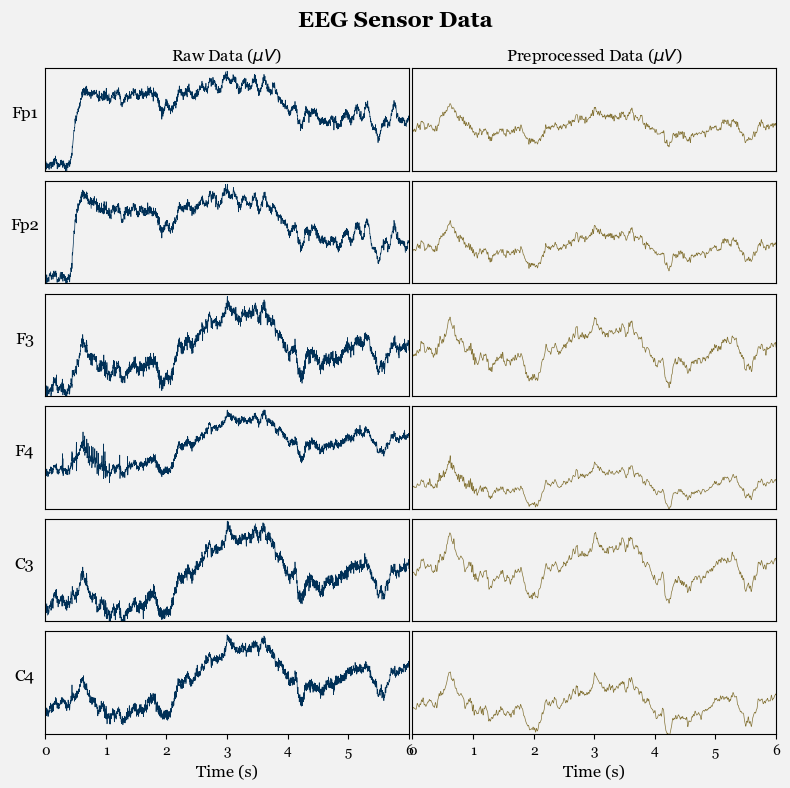

```python
obj_partic = 'sub-001'
filt_secs = 6

vis_raw = data_raw.query('participant_id == @obj_partic & time_s <= @filt_secs')
vis_pre = data_pre.query('participant_id == @obj_partic & time_s <= @filt_secs')

test_sensors = SENSORS[:6]

fig, ax = plt.subplots(len(test_sensors), 2, figsize=(8,8))

for i, sensor in enumerate(test_sensors):
    ax[i,0].plot(vis_raw.time_s, vis_raw[sensor], color = PALETTE[0], linewidth = 0.5, label = 'Raw')
    ax[i,1].plot(vis_pre.time_s, vis_pre[sensor], color = PALETTE[2], linewidth = 0.5, label = 'Preprocessed')

    ax[i,0].set_ylabel(sensor, fontsize=12, rotation=0, labelpad=15)
    max_y, min_y = max(vis_raw[sensor].max(), vis_pre[sensor].max()), min(vis_raw[sensor].min(), vis_pre[sensor].min())

    for j in range(0, len(ax[i])):
        ax[i,j].set_yticks([])
        ax[i,j].set_ylim(min_y-min_y*0.05, max_y + max_y*0.05)
        ax[i,j].set_xlim(0, filt_secs)
        ax[i,j].patch.set_facecolor('#F2F2F2')


        if i != len(test_sensors) - 1:
            ax[i,j].set_xticks([])
        else:
            ax[i,j].set_xlabel('Time (s)', fontsize=12)
            ax[i,j].set_xlabel('Time (s)', fontsize=12)

    if i == 0:
        ax[i,0].set_title('Raw Data ($\mu V$)', fontsize=12)
        ax[i,1].set_title('Preprocessed Data ($\mu V$)', fontsize=12)

fig.patch.set_facecolor('#F2F2F2')
plt.suptitle('EEG Sensor Data', fontsize=16, fontweight='bold',)
plt.tight_layout()
plt.subplots_adjust(hspace=0.1, wspace=0.01)
plt.show()
```

# PSD & RBP Transformations

This code uses the same parameters as the paper. With a segment duration of 4 seconds and a 50% overlap, this means that there is a rolling window of 2 seconds for the PSD and RBP calculations. The code that calculates the PSD and RBP uses the `welch` function from `scipy.signal`. See `helpers/calcs.py` for the detailed implementation.

```python
seg_dur = 4000  # 4 seconds in milliseconds
overlap = 0.5  # 50% overlap
step_size_ms = int(seg_dur * (1 - overlap))  # Step size accounting for overlap

dfs = []
for c, p_id in enumerate(data_pre['participant_id'].unique()):
    if c > 0:
        break

    tmp = data_pre[data_pre['participant_id'] == p_id]
    max_time = tmp['time_ms'].max()
    rows = []
    for seg_start in range(0, max_time + step_size_ms, step_size_ms):
        seg_end = seg_start + seg_dur
        seg = tmp[(tmp['time_ms'] >= seg_start) & (tmp['time_ms'] < seg_end)]

        if not seg.empty:
            cols = []
            for sens in SENSORS:
                seg_array = seg[sens].to_numpy()

                # Calculate RBP for each band using Welch's method
                tmp_power = calc_rbp(seg_array,sens)
                tmp_power = pd.DataFrame(tmp_power, index = [0])

                # Add add sensor to the same row
                cols.append(tmp_power)

            tmp_row = pd.concat(cols, axis=1)
            tmp_row.insert(0, 'participant_id', p_id)
            tmp_row.insert(1, 'seg_start', seg_start)
            tmp_row.insert(2, 'seg_end', seg_end)
            rows.append(tmp_row)

        elif seg_start <= max_time:
            #only print if there actually should be data
            print(f'P {p_id} has no data between {seg_start} and {seg_end} ms')
        else:
            pass

    dfs.append(pd.concat(rows))

epoch_data = pd.concat(dfs, ignore_index=True)
epoch_data
```

|  | participant_id | seg_start | seg_end | Fp1_delta_psd | Fp1_delta_rbp | Fp1_theta_psd | Fp1_theta_rbp | Fp1_alpha_psd | Fp1_alpha_rbp | Fp1_beta_psd | Fp1_beta_rbp | Fp1_gamma_psd | Fp1_gamma_rbp | Fp2_delta_psd | Fp2_delta_rbp | Fp2_theta_psd | Fp2_theta_rbp | Fp2_alpha_psd | Fp2_alpha_rbp | Fp2_beta_psd | Fp2_beta_rbp | Fp2_gamma_psd | Fp2_gamma_rbp | F3_delta_psd | F3_delta_rbp | F3_theta_psd | F3_theta_rbp | F3_alpha_psd | F3_alpha_rbp | … |
| --- | --- | --- | --- | --- | --- | --- | --- | --- | --- | --- | --- | --- | --- | --- | --- | --- | --- | --- | --- | --- | --- | --- | --- | --- | --- | --- | --- | --- | --- | --- |
| 0 | sub-001 | 0 | 4000 | 122.883514 | 0.760544 | 15.706409 | 0.097209 | 4.986570 | 0.030863 | 7.082795 | 0.043836 | 10.913929 | 0.067548 | 118.405029 | 0.768351 | 17.356348 | 0.112628 | 4.432917 | 0.028766 | 5.584762 | 0.036241 | 8.323713 | 0.054014 | 104.130196 | 0.776080 | 17.199083 | 0.128184 | 3.872688 | 0.028863 | … |
| 1 | sub-001 | 2000 | 6000 | 108.598663 | 0.721266 | 17.022022 | 0.113053 | 5.988880 | 0.039776 | 8.297111 | 0.055106 | 10.660148 | 0.070800 | 104.651840 | 0.740349 | 18.015253 | 0.127447 | 5.620972 | 0.039765 | 6.379345 | 0.045130 | 6.687346 | 0.047309 | 105.599388 | 0.788859 | 15.694423 | 0.117242 | 4.957615 | 0.037035 | … |
| 2 | sub-001 | 4000 | 8000 | 104.511673 | 0.717135 | 16.511761 | 0.113300 | 4.263182 | 0.029253 | 8.545684 | 0.058639 | 11.902703 | 0.081674 | 98.950623 | 0.725971 | 18.001373 | 0.132071 | 4.490857 | 0.032948 | 7.080957 | 0.051951 | 7.777321 | 0.057060 | 93.044113 | 0.772913 | 14.580393 | 0.121119 | 4.005367 | 0.033272 | … |
| 3 | sub-001 | 6000 | 10000 | 84.556618 | 0.656677 | 18.237455 | 0.141634 | 6.144132 | 0.047716 | 7.310877 | 0.056777 | 12.515235 | 0.097195 | 84.424843 | 0.662112 | 21.127480 | 0.165695 | 6.442316 | 0.050525 | 6.619747 | 0.051916 | 8.893942 | 0.069752 | 81.879395 | 0.716131 | 18.337023 | 0.160379 | 5.137866 | 0.044937 | … |
| 4 | sub-001 | 8000 | 12000 | 98.798965 | 0.690216 | 18.818378 | 0.131466 | 5.648847 | 0.039463 | 8.280874 | 0.057851 | 11.595076 | 0.081004 | 100.447601 | 0.705150 | 21.789625 | 0.152965 | 5.380560 | 0.037772 | 6.877181 | 0.048278 | 7.953551 | 0.055835 | 96.058075 | 0.761681 | 17.505749 | 0.138810 | 4.547945 | 0.036062 | … |
| ... | ... | ... | ... | ... | ... | ... | ... | ... | ... | ... | ... | ... | ... | ... | ... | ... | ... | ... | ... | ... | ... | ... | ... | ... | ... | ... | ... | ... | ... | … |
| 295 | sub-001 | 590000 | 594000 | 200.445404 | 0.862877 | 15.126671 | 0.065117 | 4.391953 | 0.018906 | 5.698197 | 0.024530 | 6.636762 | 0.028570 | 204.086548 | 0.888226 | 12.345183 | 0.053729 | 4.643804 | 0.020211 | 4.406614 | 0.019178 | 4.286529 | 0.018656 | 186.956085 | 0.893512 | 10.820612 | 0.051715 | 3.963627 | 0.018943 | … |
| 296 | sub-001 | 592000 | 596000 | 100.954178 | 0.752195 | 18.016066 | 0.134235 | 3.904130 | 0.029089 | 5.005059 | 0.037292 | 6.333274 | 0.047188 | 98.992157 | 0.772080 | 16.897614 | 0.131791 | 3.943337 | 0.030756 | 4.406867 | 0.034371 | 3.974948 | 0.031002 | 87.698158 | 0.782625 | 14.615408 | 0.130429 | 3.360373 | 0.029988 | … |
| 297 | sub-001 | 594000 | 598000 | 148.006226 | 0.789558 | 21.743210 | 0.115992 | 5.101723 | 0.027216 | 6.861657 | 0.036604 | 5.741603 | 0.030629 | 145.360184 | 0.806530 | 20.417128 | 0.113284 | 5.017638 | 0.027840 | 5.577388 | 0.030946 | 3.856846 | 0.021400 | 138.507446 | 0.836070 | 16.133184 | 0.097384 | 3.878655 | 0.023413 | … |
| 298 | sub-001 | 596000 | 600000 | 167.843933 | 0.804005 | 19.386559 | 0.092865 | 6.673707 | 0.031968 | 7.916246 | 0.037920 | 6.939484 | 0.033241 | 159.141876 | 0.827217 | 17.798527 | 0.092516 | 5.702301 | 0.029640 | 5.195565 | 0.027006 | 4.543930 | 0.023619 | 145.644180 | 0.835387 | 15.900912 | 0.091205 | 5.099349 | 0.029249 | … |
| 299 | sub-001 | 598000 | 602000 | 90.997887 | 0.674401 | 17.372612 | 0.128751 | 9.354059 | 0.069324 | 8.485937 | 0.062891 | 8.721045 | 0.064633 | 93.425392 | 0.737868 | 15.422277 | 0.121804 | 6.690961 | 0.052845 | 5.600379 | 0.044231 | 5.476353 | 0.043252 | 89.978416 | 0.785361 | 9.956960 | 0.086908 | 5.909514 | 0.051580 | … |

300 rows × 193 columns

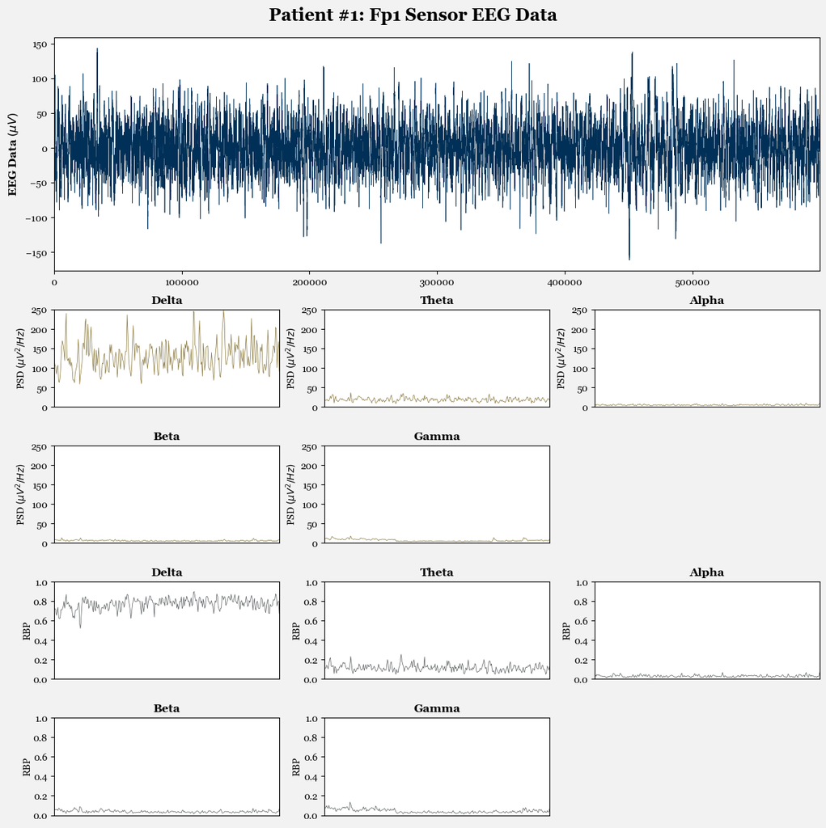

```python
comp_pre = data_pre.query('participant_id == @obj_partic')
comp_pre = comp_pre[['participant_id', 'time_s', 'time_ms', 'Fp1', ]]

comp_rbp = epoch_data.query('participant_id == @obj_partic')
const_cols = ['participant_id', 'seg_start', 'seg_end']
keep_rbp = [i for i in comp_rbp.columns if i.startswith('Fp1') and i.endswith('rbp')]
comp_rbp = comp_rbp[const_cols + keep_rbp]

comp_psd = epoch_data.query('participant_id == @obj_partic')
keep_psd = [i for i in comp_psd.columns if i.startswith('Fp1') and i.endswith('psd')]
comp_psd = comp_psd[const_cols + keep_psd]
max_y_psd = ceil(comp_psd[keep_psd].max().max()/10)*10


fig = plt.figure(figsize=(12,12))
ax01 = plt.subplot2grid((6, 3), (0, 0), colspan=3, rowspan=2)
ax02 = plt.subplot2grid((6, 3), (2, 0), rowspan=1, colspan=1)
ax03 = plt.subplot2grid((6, 3), (2, 1), rowspan=1, colspan=1)
ax04 = plt.subplot2grid((6, 3), (2, 2), rowspan=1, colspan=1)
ax05 = plt.subplot2grid((6, 3), (3, 0), rowspan=1, colspan=1)
ax06 = plt.subplot2grid((6, 3), (3, 1), rowspan=1, colspan=1)
# ax07 = plt.subplot2grid((6, 3), (3, 2), rowspan=1, colspan=1)
ax08 = plt.subplot2grid((6, 3), (4, 0), rowspan=1, colspan=1)
ax09 = plt.subplot2grid((6, 3), (4, 1), rowspan=1, colspan=1)
ax10 = plt.subplot2grid((6, 3), (4, 2), rowspan=1, colspan=1)
ax11 = plt.subplot2grid((6, 3), (5, 0), rowspan=1, colspan=1)
ax12 = plt.subplot2grid((6, 3), (5, 1), rowspan=1, colspan=1)
# ax13 = plt.subplot2grid((6, 3), (5, 2), rowspan=1, colspan=1)

ax01.plot(comp_pre.time_ms, comp_pre.Fp1, color = PALETTE[0], linewidth = 0.5)
ax01.set_ylabel('Fp1', fontsize=12, rotation=0, labelpad=15)
ax01.set_xlim(0, max(comp_pre.time_ms))
ax01.set_ylabel('EEG Data $(\mu V)$', fontsize=12, labelpad=5, fontweight='bold', rotation=90)
ax02.set_xticks([])


ax02.plot(comp_psd.seg_start, comp_psd.Fp1_delta_psd, color = PALETTE[2], linewidth = 0.5)
ax02.set_title('Delta', fontsize=12, fontweight='bold')
ax02.set_ylabel('PSD $(\mu V^2/Hz)$', labelpad=1)
ax02.set_ylim(0, max_y_psd)
ax02.set_xlim(0, max(comp_psd.seg_start))
ax02.set_xticks([])

ax03.plot(comp_psd.seg_start, comp_psd.Fp1_theta_psd, color = PALETTE[2], linewidth = 0.5)
ax03.set_title('Theta', fontsize=12, fontweight='bold')
ax03.set_ylabel('PSD $(\mu V^2/Hz)$', labelpad=1)
ax03.set_ylim(0, max_y_psd)
ax03.set_xlim(0, max(comp_psd.seg_start))
ax03.set_xticks([])

ax04.plot(comp_psd.seg_start, comp_psd.Fp1_alpha_psd, color = PALETTE[2], linewidth = 0.5)
ax04.set_title('Alpha', fontsize=12, fontweight='bold')
ax04.set_ylabel('PSD $(\mu V^2/Hz)$', labelpad=1)
ax04.set_ylim(0, max_y_psd)
ax04.set_xlim(0, max(comp_psd.seg_start))
ax04.set_xticks([])

ax05.plot(comp_psd.seg_start, comp_psd.Fp1_beta_psd, color = PALETTE[2], linewidth = 0.5)
ax05.set_title('Beta', fontsize=12, fontweight='bold')
ax05.set_ylabel('PSD $(\mu V^2/Hz)$', labelpad=1)
ax05.set_ylim(0, max_y_psd)
ax05.set_xlim(0, max(comp_psd.seg_start))
ax05.set_xticks([])

ax06.plot(comp_psd.seg_start, comp_psd.Fp1_gamma_psd, color = PALETTE[2], linewidth = 0.5)
ax06.set_title('Gamma', fontsize=12, fontweight='bold')
ax06.set_ylabel('PSD $(\mu V^2/Hz)$', labelpad=1)
ax06.set_ylim(0, max_y_psd)
ax06.set_xlim(0, max(comp_psd.seg_start))
ax06.set_xticks([])

ax08.plot(comp_rbp.seg_start, comp_rbp.Fp1_delta_rbp, color = PALETTE[4], linewidth = 0.5)
ax08.set_title('Delta', fontsize=12, fontweight='bold')
ax08.set_ylabel('RBP', labelpad=1)
ax08.set_ylim(0, 1)
ax08.set_xlim(0, max(comp_rbp.seg_start))
ax08.set_xticks([])

ax09.plot(comp_rbp.seg_start, comp_rbp.Fp1_theta_rbp, color = PALETTE[4], linewidth = 0.5)
ax09.set_title('Theta', fontsize=12, fontweight='bold')
ax09.set_ylabel('RBP', labelpad=1)
ax09.set_ylim(0, 1)
ax09.set_xlim(0, max(comp_rbp.seg_start))
ax09.set_xticks([])

ax10.plot(comp_rbp.seg_start, comp_rbp.Fp1_alpha_rbp, color = PALETTE[4], linewidth = 0.5)
ax10.set_title('Alpha', fontsize=12, fontweight='bold')
ax10.set_ylabel('RBP', labelpad=1)
ax10.set_ylim(0, 1)
ax10.set_xlim(0, max(comp_rbp.seg_start))
ax10.set_xticks([])

ax11.plot(comp_rbp.seg_start, comp_rbp.Fp1_beta_rbp, color = PALETTE[4], linewidth = 0.5)
ax11.set_title('Beta', fontsize=12, fontweight='bold')
ax11.set_ylabel('RBP', labelpad=1)
ax11.set_ylim(0, 1)
ax11.set_xlim(0, max(comp_rbp.seg_start))
ax11.set_xticks([])

ax12.plot(comp_rbp.seg_start, comp_rbp.Fp1_gamma_rbp, color = PALETTE[4], linewidth = 0.5)
ax12.set_title('Gamma', fontsize=12, fontweight='bold')
ax12.set_ylabel('RBP', labelpad=1)
ax12.set_ylim(0, 1)
ax12.set_xlim(0, max(comp_rbp.seg_start))
ax12.set_xticks([])

fig.patch.set_facecolor('#F2F2F2')
plt.suptitle('Patient #1: Fp1 Sensor EEG Data', fontsize=18, fontweight='bold', y=.99)
plt.tight_layout()
plt.subplots_adjust(hspace=0.4, wspace=0.2)
plt.show()
```

# Export Source Code

```python
user = str(pathlib.Path.home()).split('\\')[-1]
export_flag = False
if user != 'bkeith' and user != 'Brian':
    raise Exception('User running code is not the student. No need to run below.')
else:
    export_flag = True
    print('User running code is the student. Continue to file Export.')

cur_file = __vsc_ipynb_file__
output_dir = 'zlogs'
output_name = cur_file.split('\\')[-1].split('.')[0] + f'.html'
cell_tags_exist = False
template = 'classic'

if export_flag == True:
    export_code(cur_file,output_dir, output_name, cell_tags_exist, template=template)
```

```
User running code is the student. Continue to file Export.
```